# InVivoStat Repeated Measures Parametric Analysis

## Response, covariates and covariance structure

The Resp 1 response is currently being analysed by the Repeated Measures Parametric Analysis module, with Cov1, Cov6 and Cov7 fitted as covariates.

The response has been log10 transformed prior to analysis.

The repeated measures mixed model analysis is using the compound symmetric covariance structure to model the within-subject correlations. When using this structure you are assuming sphericity and also that the variability of responses is the same at each level of Day 1, see Pinherio and Bates (2002). These assumptions may not hold in practice.

The analysis implements the Kenward-Roger approximation of the degrees of freedom, see Kenward and Roger (1997).

## Categorised case profiles plot of the observed data (on the log10 scale)

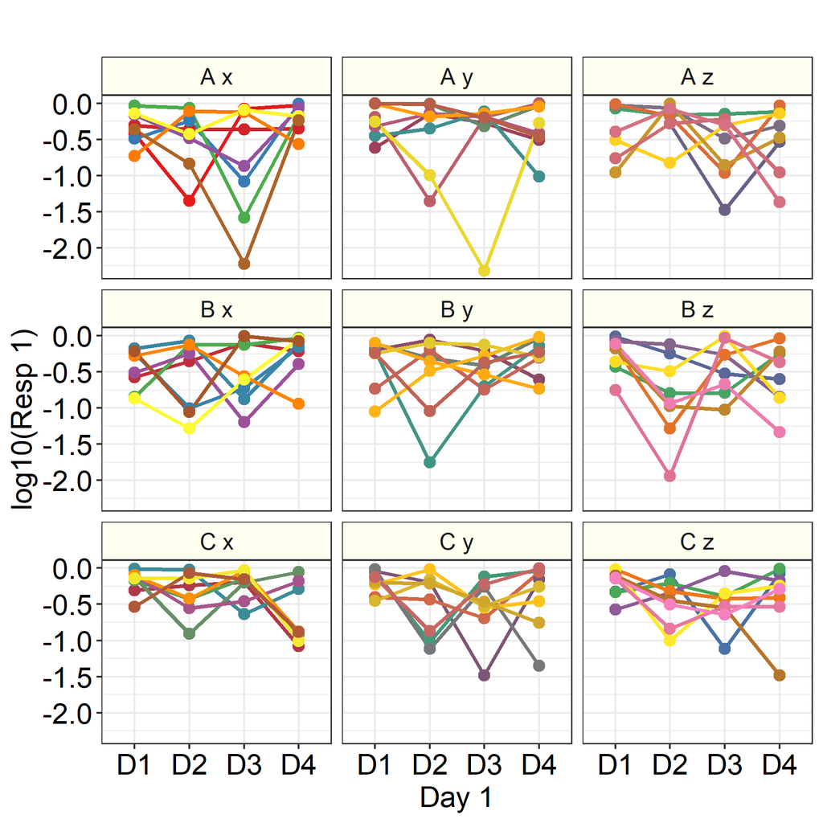

## Plot of the response vs. the covariates (on the transformed scale), categorised by the primary factor

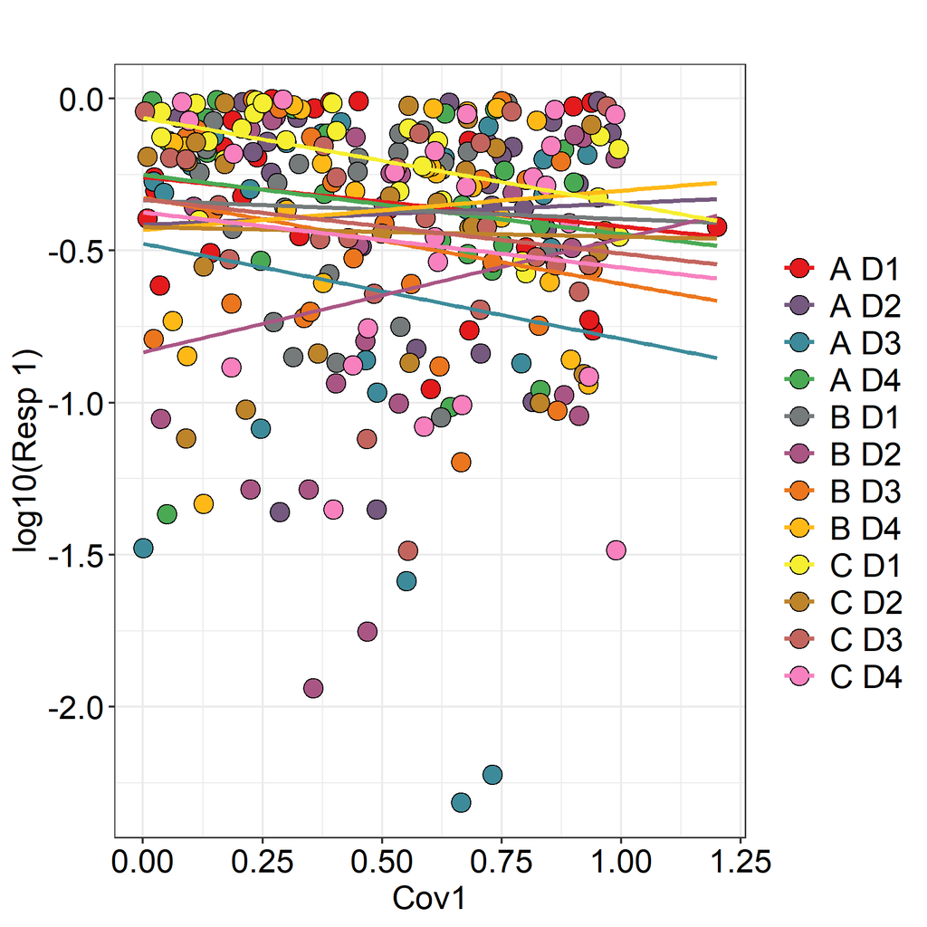

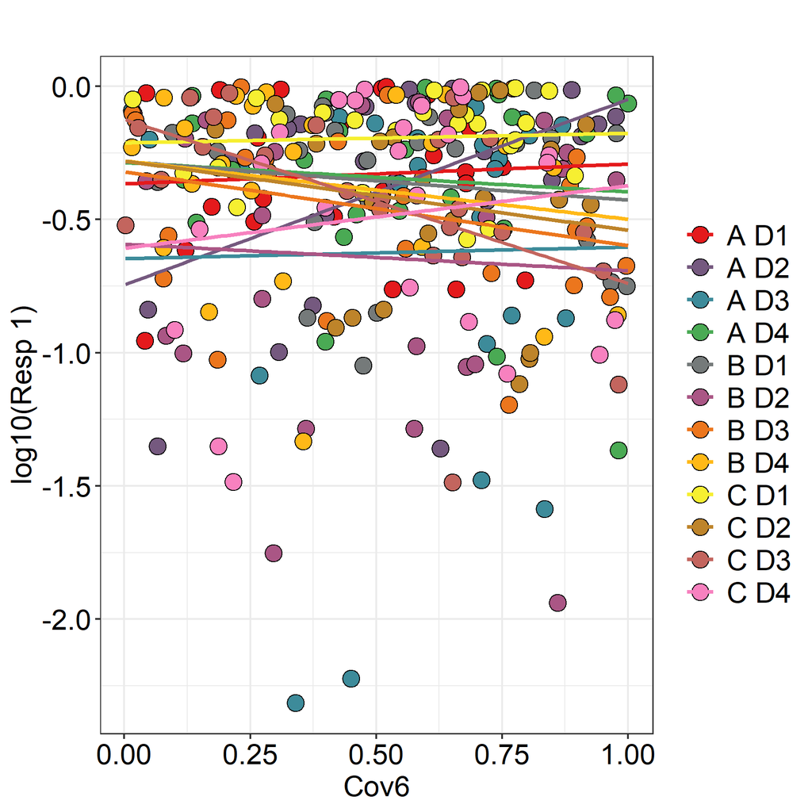

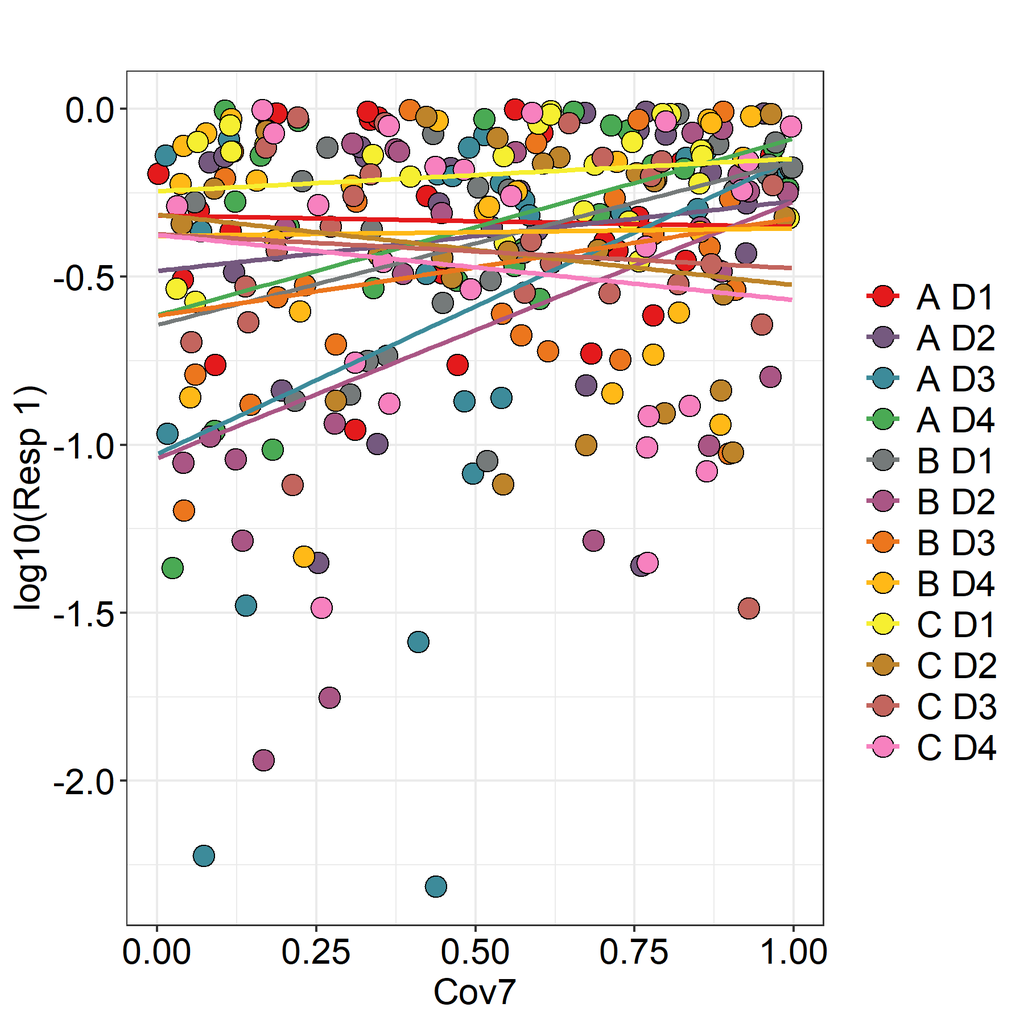

Tip: In order to decide whether it is helpful to fit the covariate, the following should be considered:

a) Is there a relationship between the response and the covariate? (N.B., It is only worth fitting the covariate if there is a strong positive (or negative) relationship between them: i.e., the lines on the plot should not be horizontal).

b) Is the relationship similar for all treatments? (The lines on the plot should be approximately parallel).

c) Is the covariate influenced by the treatment? (We assume the covariate is not influenced by the treatment and so there should be no separation of the treatment groups along the x-axis on the plot).

These issues are discussed in more detail in Morris (1999).

## Table of overall tests of model effects, for assessing covariate interactions

| Effect | Num. degrees of freedom | Denom. degrees of freedom | F-value | p-value |
| --- | --- | --- | --- | --- |
| Cov1 | 1 | 219.59 | 0.73 | 0.3949 |
| Cov6 | 1 | 227.28 | 0.37 | 0.5428 |
| Cov7 | 1 | 227.84 | 5.81 | 0.0167 |
| Treat 1 | 2 | 215.86 | 1.76 | 0.1745 |
| Treat 2 | 2 | 215.77 | 0.64 | 0.5297 |
| Day 1 | 3 | 225.72 | 1.33 | 0.2647 |
| Treat 1 * Treat 2 | 4 | 59.29 | 0.37 | 0.8325 |
| Treat 1 * Day 1 | 6 | 177.77 | 1.46 | 0.1930 |
| Treat 2 * Day 1 | 6 | 179.89 | 0.26 | 0.9534 |
| Cov1 * Treat 1 | 2 | 215.42 | 0.49 | 0.6105 |
| Cov6 * Treat 1 | 2 | 225.67 | 0.40 | 0.6693 |
| Cov7 * Treat 1 | 2 | 226.75 | 2.60 | 0.0762 |
| Cov1 * Day 1 | 3 | 223.99 | 0.38 | 0.7648 |
| Cov6 * Day 1 | 3 | 224.10 | 1.23 | 0.3012 |
| Cov7 * Day 1 | 3 | 217.02 | 0.30 | 0.8283 |
| Cov1 * Treat 2 | 2 | 218.14 | 0.33 | 0.7204 |
| Cov6 * Treat 2 | 2 | 225.34 | 0.09 | 0.9106 |
| Cov7 * Treat 2 | 2 | 227.63 | 0.93 | 0.3943 |
| Treat 1 * Treat 2:Day 1 | 12 | 177.46 | 0.84 | 0.6128 |

Note: This table should only be used to assess the covariate interactions. The statistical model used to generate all the remaining results in this output does not include the covariate interactions.

## Comparing models with different covariance structures

| Covariance Structure | Akaike information criterion (AIC) | Bayesian information criterion (BIC) | Log-Likelihood |
| --- | --- | --- | --- |
| Compound Symmetric | 331.934 | 336.487 | -163.967 |
| Autoregressive (1) | 333.129 | 337.682 | -164.564 |
| Unstructured | 319.420 | 342.187 | -149.710 |

Note: When comparing covariance structures, a lower AIC or BIC value indicates a better fit.

## Table of overall tests of model effects

| Effect | Num. degrees of freedom | Denom. degrees of freedom | F-value | p-value |
| --- | --- | --- | --- | --- |
| Cov1 | 1 | 239.19 | 1.26 | 0.2621 |
| Cov6 | 1 | 248.86 | 0.34 | 0.5599 |
| Cov7 | 1 | 248.94 | 7.10 | 0.0082 |
| Treat 1 | 2 | 63.07 | 1.14 | 0.3274 |
| Treat 2 | 2 | 63.04 | 0.51 | 0.6007 |
| Day 1 | 3 | 187.43 | 3.57 | 0.0151 |
| Treat 1 * Treat 2 | 4 | 62.18 | 0.56 | 0.6960 |
| Treat 1 * Day 1 | 6 | 187.37 | 1.78 | 0.1043 |
| Treat 2 * Day 1 | 6 | 188.21 | 0.20 | 0.9771 |
| Treat 1 * Treat 2:Day 1 | 12 | 187.71 | 1.17 | 0.3064 |

Conclusion: At the 5% level there is a statistically significant overall difference between the levels of Cov7 and Day 1.

Tip: While it is a good idea to consider the overall tests in the above table, we should not rely on them when deciding whether or not to make pairwise comparisons.

## Covariate regression coefficients

| Covariate | Estimate | Std error | t-value | p-value |
| --- | --- | --- | --- | --- |
| Cov1 | -0.096 | 0.086 | -1.12 | 0.2621 |
| Cov6 | -0.055 | 0.094 | -0.58 | 0.5599 |
| Cov7 | 0.222 | 0.083 | 2.66 | 0.0082 |

## Diagnostic plots

### Residuals vs. predicted plot

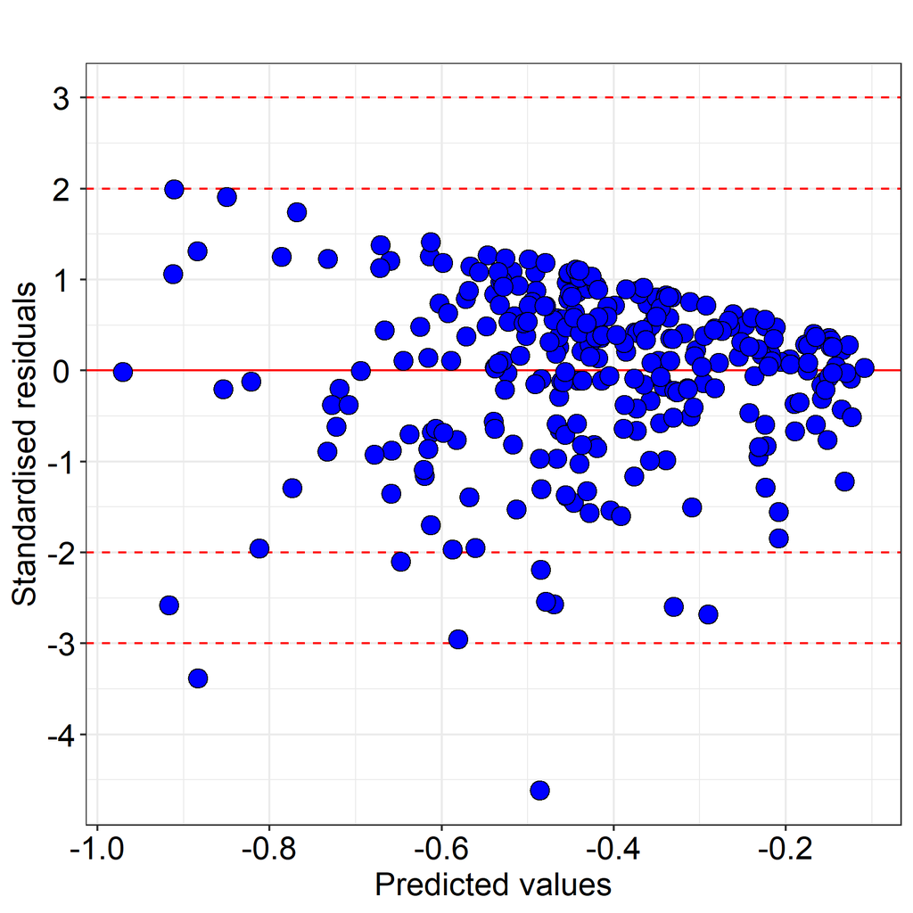

Tip: On this plot look to see if the spread of the points increases as the predicted values increase. If so the response may need transforming.

Tip: Any observation with a standardised residual less than -3 or greater than 3 (SD) should be investigated as a possible outlier.

Comment: The standardised residuals are obtained by subtracting the fitted values from the responses and dividing by the estimated within-group standard error.

### Normal probability plot

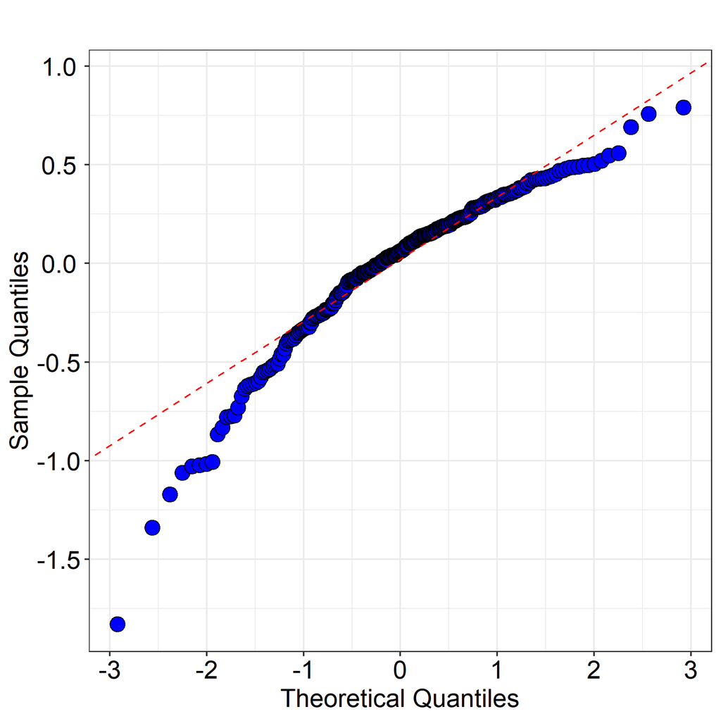

Tip: Check that the points lie along the dotted line. If not then the data may be non-normally distributed.

## Table of the least square (predicted) means with 95% confidence intervals

| Mean ID | Treat 1 | Day 1 | Mean | Lower 95% CI | Upper 95% CI |
| --- | --- | --- | --- | --- | --- |
| 1 | A | D1 | -0.325 | -0.485 | -0.164 |
| 2 | B | D1 | -0.380 | -0.541 | -0.220 |
| 3 | C | D1 | -0.200 | -0.360 | -0.040 |
| 4 | A | D2 | -0.364 | -0.524 | -0.204 |
| 5 | B | D2 | -0.642 | -0.801 | -0.482 |
| 6 | C | D2 | -0.450 | -0.610 | -0.289 |
| 7 | A | D3 | -0.609 | -0.769 | -0.449 |
| 8 | B | D3 | -0.466 | -0.625 | -0.307 |
| 9 | C | D3 | -0.423 | -0.583 | -0.264 |
| 10 | A | D4 | -0.343 | -0.503 | -0.184 |
| 11 | B | D4 | -0.369 | -0.529 | -0.208 |
| 12 | C | D4 | -0.479 | -0.639 | -0.319 |

## Plot of the least square (predicted) means with 95% confidence intervals

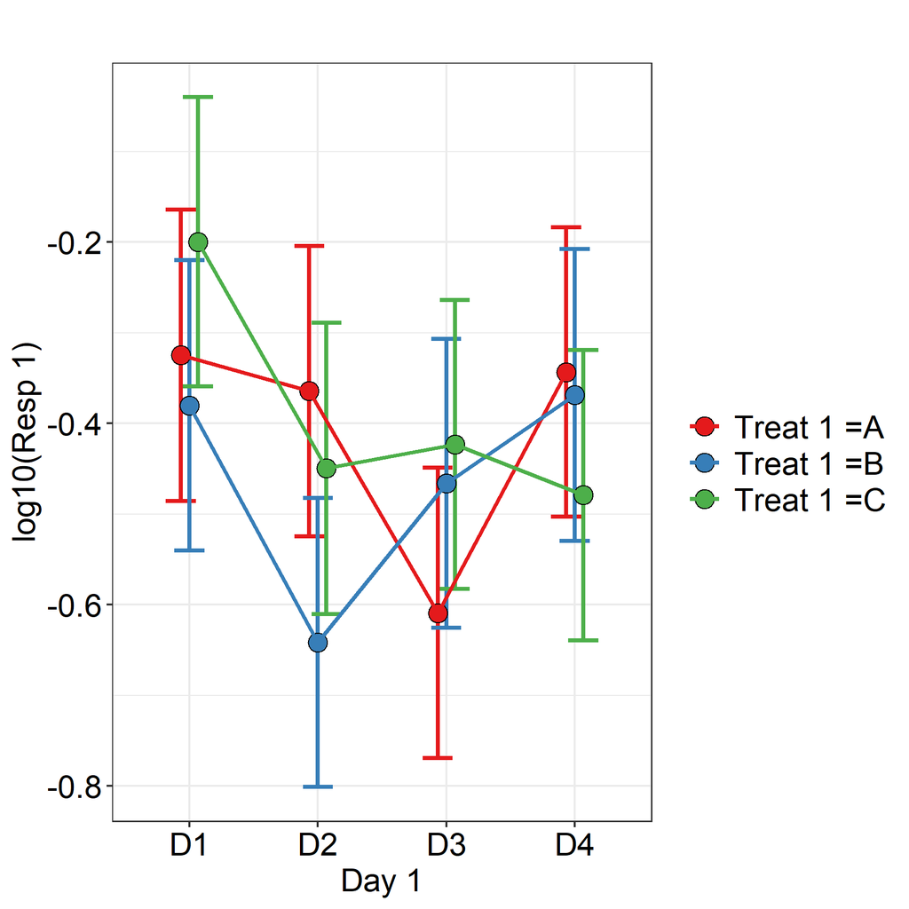

## Table of the back-transformed geometric means with 95% confidence intervals

As the response was log transformed prior to analysis the least square (predicted) means are presented on the log scale. These results can be back transformed onto the original scale. These are known as the back-transformed geometric means.

| Mean ID | Treat 1 | Day 1 | Geometric mean | Lower 95% CI | Upper 95% CI |
| --- | --- | --- | --- | --- | --- |
| 1 | A | D1 | 0.473 | 0.327 | 0.685 |
| 2 | B | D1 | 0.416 | 0.288 | 0.602 |
| 3 | C | D1 | 0.631 | 0.437 | 0.911 |
| 4 | A | D2 | 0.432 | 0.299 | 0.625 |
| 5 | B | D2 | 0.228 | 0.158 | 0.330 |
| 6 | C | D2 | 0.355 | 0.245 | 0.514 |
| 7 | A | D3 | 0.246 | 0.170 | 0.356 |
| 8 | B | D3 | 0.342 | 0.237 | 0.493 |
| 9 | C | D3 | 0.377 | 0.261 | 0.545 |
| 10 | A | D4 | 0.454 | 0.314 | 0.655 |
| 11 | B | D4 | 0.428 | 0.295 | 0.620 |
| 12 | C | D4 | 0.332 | 0.229 | 0.480 |

## Plot of the back-transformed geometric means with 95% confidence intervals

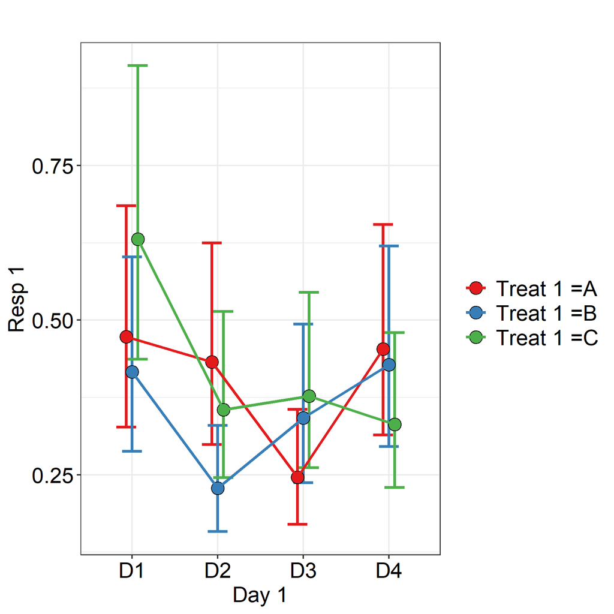

## Pairwise comparisons within the levels of the repeated factor, without adjustment for multiplicity

| Comparison | Difference | Lower 95% CI | Upper 95% CI | Std error | p-value |
| --- | --- | --- | --- | --- | --- |
| ( A , D1 ) - ( B , D1 ) | 0.055 | -0.172 | 0.282 | 0.12 | 0.6313 |
| ( A , D1 ) - ( C , D1 ) | -0.125 | -0.352 | 0.102 | 0.12 | 0.2781 |
| ( B , D1 ) - ( C , D1 ) | -0.180 | -0.406 | 0.045 | 0.11 | 0.1162 |
| ( A , D2 ) - ( B , D2 ) | 0.277 | 0.051 | 0.503 | 0.11 | 0.0164 |
| ( A , D2 ) - ( C , D2 ) | 0.085 | -0.141 | 0.312 | 0.12 | 0.4581 |
| ( B , D2 ) - ( C , D2 ) | -0.192 | -0.419 | 0.035 | 0.12 | 0.0972 |
| ( A , D3 ) - ( B , D3 ) | -0.143 | -0.369 | 0.083 | 0.11 | 0.2136 |
| ( A , D3 ) - ( C , D3 ) | -0.186 | -0.412 | 0.040 | 0.11 | 0.1071 |
| ( B , D3 ) - ( C , D3 ) | -0.043 | -0.268 | 0.183 | 0.11 | 0.7081 |
| ( A , D4 ) - ( B , D4 ) | 0.025 | -0.202 | 0.252 | 0.12 | 0.8272 |
| ( A , D4 ) - ( C , D4 ) | 0.136 | -0.090 | 0.362 | 0.11 | 0.2378 |
| ( B , D4 ) - ( C , D4 ) | 0.111 | -0.117 | 0.338 | 0.12 | 0.3390 |

## Pairwise comparisons within the levels of the repeated factor, as back-transformed ratios

As the response was log transformed prior to analysis the differences between the least square (predicted) means are presented on the log scale. These results can be back-transformed, where differences on the log scale become ratios when back-transformed.

| Comparison | Ratio | Lower 95% CI | Upper 95% CI | p-value |
| --- | --- | --- | --- | --- |
| ( A , D1 ) / ( B , D1 ) | 1.136 | 0.673 | 1.916 | 0.6313 |
| ( A , D1 ) / ( C , D1 ) | 0.750 | 0.445 | 1.263 | 0.2781 |
| ( B , D1 ) / ( C , D1 ) | 0.660 | 0.393 | 1.109 | 0.1162 |
| ( A , D2 ) / ( B , D2 ) | 1.894 | 1.126 | 3.187 | 0.0164 |
| ( A , D2 ) / ( C , D2 ) | 1.218 | 0.723 | 2.051 | 0.4581 |
| ( B , D2 ) / ( C , D2 ) | 0.643 | 0.381 | 1.084 | 0.0972 |
| ( A , D3 ) / ( B , D3 ) | 0.720 | 0.428 | 1.210 | 0.2136 |
| ( A , D3 ) / ( C , D3 ) | 0.652 | 0.387 | 1.098 | 0.1071 |
| ( B , D3 ) / ( C , D3 ) | 0.906 | 0.539 | 1.522 | 0.7081 |
| ( A , D4 ) / ( B , D4 ) | 1.060 | 0.628 | 1.787 | 0.8272 |
| ( A , D4 ) / ( C , D4 ) | 1.367 | 0.812 | 2.301 | 0.2378 |
| ( B , D4 ) / ( C , D4 ) | 1.290 | 0.764 | 2.179 | 0.3390 |

Conclusion: The following pairwise comparisons are statistically significant at the 5% level: (1) ( A , D2 ) vs. ( B , D2 ).

Warning: As these tests are not adjusted for multiplicity there is a risk of false positive results. Only use the pairwise comparisons you planned to make a-priori, these are the so called Planned Comparisons, see Snedecor and Cochran (1989). No options are available in this module to make multiple comparison adjustments. If you wish to apply a multiple comparison adjustment to these results then use the P-value Adjustment module.

## Analysis description

The data were analysed using a 3-way repeated measures mixed model approach utilizing the mmrm R package, with Treat 1 and Treat 2 as treatment factors, Day 1 as the repeated factor and Cov1, Cov6 and Cov7 as covariates.This was followed by Planned Comparisons on the predicted means to compare the levels of the effect Treat 1 * Day 1. The response was log10 transformed prior to analysis to stabilise the variance.

The compound symmetric covariance structure was used to model the within-subject correlations. When using this structure we assumed that the variability of the responses was the same at each level of Day 1 and the correlation between responses from any pair of levels of Day 1 is the same.

The analysis implements the Kenward-Roger approximation of the degrees of freedom, see Kenward and Roger (1997).

A full description of mixed model theory can be found in Venables and Ripley (2003) and Pinherio and Bates (2002).

For more information on the theoretical approaches that are implemented within this module, see Bate and Clark (2014).

## References

When referring to InVivoStat, please cite 'InVivoStat, version 5.2.0'.

Bate, S.T. and Clark, R.A. (2014). The Design and Statistical Analysis of Animal Experiments. Cambridge University Press.

Morris, T.R. (1999). Experimental Design and Analysis in Animal Sciences. CABI publishing. Wallingford, Oxon (UK).

Kenward, M.G. and Roger J.H. (1997). Small sample inference for fixed effects from restricted maximum likelihood. Biometrics. 983-997.

Snedecor, G.W. and Cochran, W.G. (1989). Statistical Methods. 8th edition; Iowa State University Press, Iowa, USA.

Venables, W.N. and Ripley, B.D. (2003). Modern Applied Statistics with S. 4th Edition; Springer. New York, Inc.